# Lab 2: More with R and Introduction to RMarkdown

Jose M. Rodriguez Flores

02/05/2020

> Github user: joserdgz8 https://github.com/joserdgz8/es207_hw2
> 1. Using the help documentation, provide an alternative useage for the function ncol()

We can use ncol() to use other functions inside like array()

> 5. Create and print a new vector, w that is a subset of the first 4 elements of vector v, where v <- c(8:19)

```r
v<-c(8:19)
print(v)
```

```
##  [1]  8  9 10 11 12 13 14 15 16 17 18 19
```

```r
w<-c(v[1:4])
print(w)
```

```
## [1]  8  9 10 11
```

> 6. Create and print a new vector, h that is a subset of the middle 5 elements of vector d, where d <- c(8:20)

```r
d <- c(8:20)
print(d)
```

```
##  [1]  8  9 10 11 12 13 14 15 16 17 18 19 20
```

```r
h <- c(d[4:8])
print(h)
```

```
## [1] 11 12 13 14 15
```

> 7. What is the length of vector w from above?

```r
length(w)
```

```
## [1] 4
```

#### Types, Testing & Coercion of Vectors

> 8. What are the 3 properties of a vector, other than its contents?.

*Atributes* Type *Lenght

> 9. Can you predict the output of the following uses of c()? c(3,FALSE) c(“a”,1) c(4L,2)

c(3,False) makes 3,0 FALSE becomes 0: “double” c(“a”,1) creates a vector (“a”,“1”) the first elemment is a character, so R asign the second elemment as a character. c(4L,2) Results in a vector of two “double” numbers.

Proof:

```r
typeof(c(3,FALSE))
```

```
## [1] "double"
```

```r
typeof(c("a",1))
```

```
## [1] "character"
```

```r
typeof(c(4L,2))
```

```
## [1] "double"
```

> 10. What are the 4 types of common atomic vectors? What are the 2 rare types?

The four common types of atomic vectors are:

- Logical
- Integer
- Double (numeric)
- Character

The two two rare types are:

- Complex
- Raw
> 11. Why is 1==“1” true? Why is -1 < FALSE true? Why is "one< 2 false?

```r
1=="1"
```

```
## [1] TRUE
```

```r
-1<FALSE
```

```
## [1] TRUE
```

```r
"one"<2
```

```
## [1] FALSE
```

1==“1” is TRUE because the numeric 1 is compared with its correspesponding character “1”

-1<FALSE is TRUE because whe we coerce a logicalvector into an integer or double FLASE becomes 0; hence,is TRUE that -`<0

“one”<2 is FALSE becausew we are comparing a string with a number, R in this case are does not asign 1 to the string “one”

> 12. Why is the default missing value NA, a logical vector? What’s so special about logical vectors? Hint: think about c(FALSE,NA_character)

Missing values are specified with NA, which is a logical vector of length 1. NA will always be coerced to the correct type if used inside c(), or we can create NAs of a specific type with NA_real_ (a double vector), NA_integer_ and NA_character_.

> 13. Provide the value of the last element in the result of the vector operation d * 2 from the vectors defined above.

```r
l=d*2
print(l[length(l)])
```

```
## [1] 40
```

> 14. Create a vector a with a sequence of 11 elements in it ranging from 0.6 to 1.9. Create another, logical vector b that identifies which elements in a are greater than or equal to 1.1. Print your results.

```r
a=seq(from=0.6, to=1.9, length=11)
print(a)
```

```
##  [1] 0.60 0.73 0.86 0.99 1.12 1.25 1.38 1.51 1.64 1.77 1.90
```

```r
b=c(which(a>=1.1))
print(b)
```

```
## [1]  5  6  7  8  9 10 11
```

```r
a[a>=1.1]<-2.2
print(a)
```

```
##  [1] 0.60 0.73 0.86 0.99 2.20 2.20 2.20 2.20 2.20 2.20 2.20
```

> 16. Use str() to compare the results of using list() and c() on l and j for: l <-c(list(1,2),c(3,4)) and j=list(list(1,2),c(3,4))

```r
l <-c(list(1,2),c(3,4))
j=list(list(1,2),c(3,4))
str(l)
```

```
## List of 4
##  $ : num 1
##  $ : num 2
##  $ : num 3
##  $ : num 4
```

```r
str(j)
```

```
## List of 2
##  $ :List of 2
##   ..$ : num 1
##   ..$ : num 2
##  $ : num [1:2] 3 4
```

Since l uses concatenate function it coerce the vector to a list; hence, it is a list with four numbers. On the other hand j lis() keeps the identity of the object.

> 17. Show what happens when you use unlist() on l and j

```r
unlist(j)
```

```
## [1] 1 2 3 4
```

```r
unlist(l)
```

```
## [1] 1 2 3 4
```

unlist() transform both l and j to atomic vectors with four numbers.

> 18. If factors are essentially integers under the hood, why do we use them, and not just use integers (e.g., 1s and 2s instead of “male”, “female”)?

Because it help us to categorize data, and summarize data. Can be ordered and ordered. R has special methods for handling factors.

> 19. Using table(), provide the frequency of no and yes in my.fac

```r
my.fac <- factor(c("yes", "yes", "no", "yes", "yes", "yes"))
my.fac
```

```
## [1] yes yes no  yes yes yes
## Levels: no yes
```

```r
table(my.fac)
```

```
## my.fac
##  no yes
##   1   5
```

> 20. What does this R code below do? How are f1 and f2 different from f3?

```r
f1 <- factor(letters)
levels(f1) <-rev(levels(f1))
f2 <- rev(factor(letters))
f3 <- factor(letters, levels=rev(letters))
```

- f1 <- factor(letters)
- levels(f1) <-rev(levels(f1))

At the end order of factors and levels are reversed.

- f2 <- rev(factor(letters))

The order or the factor elements are reversed.

- f3 <- factor(letters, levels=rev(letters))

The order of the levels are reversed.

> 21. If is.matrix(x) is TRUE, what will is.array(x) return?

It will return also TRUE.

> 22. Why didn’t that work? Hint: read the errors

It did not work because one rule of the data frame is that al the vectors must be the same lenght. Ages has three elemnts one more than kids.

> BONUS. What is a tibble? Why might it be better than a data frame? Why might it be worse?

A tibbles are data frames, but they keep features of the original data frame. Tibbles are better than data frames because, they can print the first 10 rows and all the columns that can fit on the screen and can print the data type of each column.

> 23. What does as.matrix() do when applied to a data frame with columns of different types?

It converts its first argument into a matrix, the dimensions of which will be inferred from the input.In other words coercion into the same type of argument.

> 24. What if we don’t have the same variable name? Change the data frame variables names using names(d2) <- c(“ages”,“kids”). Then, use the help documentation to merge d1 and d2. Print your results.

```r
d1 <- data.frame(names = c("Jack", "Jill", "John"), states = c("CA", "IL", "IL"))
d2 <- data.frame(ages = c(10, 7, 12), names = c("Jill", "Jillian", "Jack"))
names(d2) <- c("ages","kids")
d3 <- merge(d1,d2)
print(d3)
```

```
##   names states ages    kids
## 1  Jack     CA   10    Jill
## 2  Jill     IL   10    Jill
## 3  John     IL   10    Jill
## 4  Jack     CA    7 Jillian
## 5  Jill     IL    7 Jillian
## 6  John     IL    7 Jillian
## 7  Jack     CA   12    Jack
## 8  Jill     IL   12    Jack
## 9  John     IL   12    Jack
```

Because we changed the variable that was used to join the data frames (names) merge repeating all the element of the variables ages and kids for every element in the dataframe d1.

> 25. Can you have a data frame with 0 rows? What about 0 columns?

YES, we can create empty data frames with a X number of columns and 0 rows, and vice versa, as well as an empty data frame.

> 26. Plot a histogram of all the Sepal.Width values in the dataset iris that are less than or equal to 3.0.

```r
attributes(iris)
```

```
## $names
## [1] "Sepal.Length" "Sepal.Width"  "Petal.Length" "Petal.Width"  "Species"
##
## $class
## [1] "data.frame"
##
## $row.names
##   [1]   1   2   3   4   5   6   7   8   9  10  11  12  13  14  15  16  17  18
##  [19]  19  20  21  22  23  24  25  26  27  28  29  30  31  32  33  34  35  36
##  [37]  37  38  39  40  41  42  43  44  45  46  47  48  49  50  51  52  53  54
##  [55]  55  56  57  58  59  60  61  62  63  64  65  66  67  68  69  70  71  72
##  [73]  73  74  75  76  77  78  79  80  81  82  83  84  85  86  87  88  89  90
##  [91]  91  92  93  94  95  96  97  98  99 100 101 102 103 104 105 106 107 108
## [109] 109 110 111 112 113 114 115 116 117 118 119 120 121 122 123 124 125 126
## [127] 127 128 129 130 131 132 133 134 135 136 137 138 139 140 141 142 143 144
## [145] 145 146 147 148 149 150
```

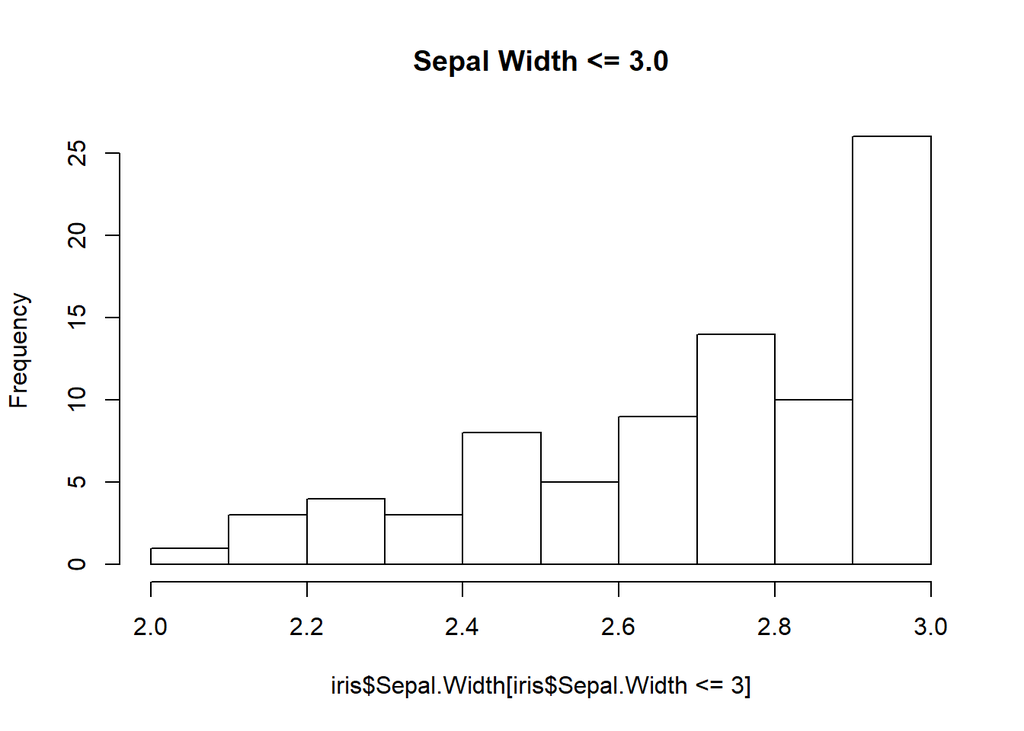

```r
hist(iris$Sepal.Width[iris$Sepal.Width<=3.0], main="Sepal Width <= 3.0")
```

> 27. Try using apply on ‘d’. What happens? Why?

```r
d <- data.frame(gender = c("M", "M", "F", "M", "F", "F"),
        age=c(47, 59, 21, 32, 33, 24),
        income=c(55000, 88000, 32450, 76500, 123000, 45650))
d$over25 <- ifelse(d$age > 25, 1, 0)
d
```

```
##   gender age income over25
## 1      M  47  55000      1
## 2      M  59  88000      1
## 3      F  21  32450      0
## 4      M  32  76500      1
## 5      F  33 123000      1
## 6      F  24  45650      0
```

```r
apply(d,2,max)
```

```
##   gender      age   income   over25
##      "M"     "59" "123000"      "1"
```

We got the maximun value of every variable (column), in the case of gender we got “M” due to its possition in the alphabet.

> 28. What are the general elements of a function? Which elements are not required?
- Name
- Argument (not required)
- Body
- Return is not required but is necessary to keep it in the global environment.
> 29. How do you pass a value of an object from the local environment to the global environment (outside of a function)?

Using the return() at the end of the function and defining what does the function will return to the global environment.

> 30. What is the name of the R function that can help you identify errors in your function?

debug(“name of the function”)

> 31. Aside from using the fucntion identified in 3. above, what is another way to troubleshoot your functions? Hint: we used this in our first function oddcount in homework 1.

Printing whats happening every step is a good way to troubleshoot our function, for example in oddcount every time the loop for make a step the function printed what was doing. Other way to troubleshoot is using stop() stopifnot() inside the function to stop the function when something can cause a bug.

> 32. What is the name of a function to write your own error messages when writing a function?.
- stop() and stopifnot()
> 33. Why do you want to keep your functions short?

It is easy to code. I can split a long function into differentand more managable functions. It will be easier to revisit one small function.

> 34. What are local versus global variables? Why do they matter when you write functions?

Local variables are those that are declared inside the function and can be used only inside that function. Global varuables are declared outside the function and can be accesed by any function.

It matters to distinguish these two variables because we must now what variables our functions are using and from where they are accessing to these variables.

> 35. What happens if you write the function as following in the code below and test it on wavelength = 0.02 m?

```r
wave_to_freq <- function(wave) {
  #note wavelength needs to be in meters
  freq <- (299792458/wave) #speed of light in m/s
  freq
}
paste("A wavelength of 10 cm has a frequency of", wave_to_freq(0.02),"Hz")
```

```
## [1] "A wavelength of 10 cm has a frequency of 14989622900 Hz"
```

> 36. Using the new function wave_to_freq(), what happens if you assign the function wave_to_freq() to object x and call x?

```r
wave_to_freq(wave_to_freq(30))
```

```
## [1] 30
```

It returns the x assigned.

> 37. Write a function that converts nanometers (nm) to meters (m). Make sure to provide useful comments. Save the function as a .R script with a logical name (e.g., “nano_to_meter”) and push it to your es207_hw2 repo in GitHub.

```r
nm_to_m <- function(x){
  print(paste("This function converts", x,"nanometers to meters"))
  meter <- x*10^(-9)
  meter
  print(paste(x,"nanometers","are",meter,"meters"))
}
```

See nano_to_meter.R in my es207_hw2 repo.

> 38.Write a function that can take wavelength in micrometers as an input, and output the equivalent value in Giga Herz (GHz).

```r
mm_to_GHz <- function(x){
  print(paste( x,"micrometers","to Giga Herz (GHz)"))
  ghz <- (299792.458/x)
  print(paste( x,"micrometers (Wavelenghth) are:",ghz,"Giga Herz"))
  return(ghz)
}
```

> 39. Using the function you wrote above, what radar band (provide the letter) corresponds to a wavelength of 30,000 micrometers? (Hint you may need to do some internet research about the frequency of different radar bands).

```r
mm_to_GHz(30000)
```

```
## [1] "30000 micrometers to Giga Herz (GHz)"
## [1] "30000 micrometers (Wavelenghth) are: 9.99308193333333 Giga Herz"
```

```
## [1] 9.993082
```

This wavelenght corresponds to the X band.

> 40. Write a for loop that caluculates the square of the first 10 elements in the vector x, where x <- rnorm(40)

```r
x <- rnorm(40)
print("This loop calculates the square of the first ten elements of the vector x")
```

```
## [1] "This loop calculates the square of the first ten elements of the vector x"
```

```r
xsq <- 0
for(i in 1:10) {
    xsq[i] <- x[i]^2
  print(xsq[i])
}
```

```
## [1] 2.404048
## [1] 0.2667638
## [1] 0.3380485
## [1] 0.6848768
## [1] 1.051214
## [1] 0.00692443
## [1] 1.313632
## [1] 4.002755
## [1] 3.623041
## [1] 0.9789768
```

> 41. Write a while loop that prints the even numbers from 4 through 29.

```r
a <- c(4:29)
print("This for loop prints the even numbers that goes from 4 through 29")
```

```
## [1] "This for loop prints the even numbers that goes from 4 through 29"
```

```r
for(i in a){
  if( i%%2 ==0 )
    print(i)
}
```

```
## [1] 4
## [1] 6
## [1] 8
## [1] 10
## [1] 12
## [1] 14
## [1] 16
## [1] 18
## [1] 20
## [1] 22
## [1] 24
## [1] 26
## [1] 28
```

> 42. Write a while loop that prints multiples of 10 from 100 to 190.

```r
i <- 100
while (i<=190)
{
  if(i %% 10==0)
  {
  print(i)
  }
  i <- i+10
}
```

```
## [1] 100
## [1] 110
## [1] 120
## [1] 130
## [1] 140
## [1] 150
## [1] 160
## [1] 170
## [1] 180
## [1] 190
```

> 43. Create a 10 x 10 matrix of random numbers. Write a loop that replaces the 3rd row and 5th column of numbers with “ciao”.

```r
ciao <- matrix(rnorm(100), ncol=10, nrow=10)
for (j in 1:dim(ciao)[1])
  {
    for(i in 1:dim(ciao)[2])
     {
      if (j==3|i==5)
          ciao[j,i]="ciao"
     }
   }
ciao
```

```
##       [,1]                   [,2]                 [,3]
##  [1,] "0.84591080754978"     "-0.517892751834925" "-0.0809437541114515"
##  [2,] "-0.00281589545266655" "1.158135525599"     "-0.309968021738191"
##  [3,] "ciao"                 "ciao"               "ciao"
##  [4,] "-0.146782771855629"   "-0.588278631882136" "1.26971768088744"
##  [5,] "1.07155464670857"     "1.37010661212423"   "-0.598862311086825"
##  [6,] "0.163501593618437"    "-1.42570300824852"  "0.110608658383932"
##  [7,] "0.850609598402068"    "0.80936644331959"   "-0.279543095724881"
##  [8,] "1.27313413623152"     "-0.527224010983396" "0.329175373474666"
##  [9,] "1.21615870746053"     "-0.622022796672802" "-1.20245654084747"
## [10,] "0.187047464424583"    "1.07074562833255"   "0.849371081397471"
##       [,4]                  [,5]   [,6]                  [,7]
##  [1,] "-0.718532282968635"  "ciao" "-0.434252770332407"  "1.49089375722797"
##  [2,] "0.798487968900293"   "ciao" "1.40454598718557"    "-2.05677363316085"
##  [3,] "ciao"                "ciao" "ciao"                "ciao"
```

[output cut: 18 more lines]

> 44. What is a loop? Can you provide me with a real-life example in either remote sensing or your own research where such a thing would be handy?.`

A loop is automating a multi-step process by organizing a sequences of actions and grouping the parts in need of repetition.

In our research we modeled land use and water use in the central valley FOR different regions and FOR different years. In the models we usually run models with loops to make the sequences of operations multiple times depending on the number of regions, irrigation districts, etc.

> 45. What does it mean to “grow” variables or datasets using a loop? Show an example of code that does this.

Grow variables or data sets meeans assinging a new object definition on every iteration, R has to create a new object and copy across the information just to add a new element or row/column

Example:

```r
set.seed(42);
m=10; n=10;
mymat<-replicate(m, rnorm(n)) # create matrix of normal random numbers
mydframe=data.frame(mymat)    # transform into data frame
for (i in 1:m) {
  for (j in 1:n) {
    mydframe[i,j]<-mydframe[i,j] + 10*sin(0.75*pi)
    print(mydframe)
  }
}
```

> 46. In 500 words or less, discuss why you would want to write loops, why some people look down on them in R, what the suggested alternative is.

Loops are one of the most powerful of programming concepts. A loop in a computer program is an instruction that repeats until a specified condition is reached. In a loop structure, the loop asks a question. If the answer requires action, it is executed. The same question is asked again and again until no further action is required. Each time the question is asked is called an iteration.

We are always looking for efficnecy in our coces; thus if we need to use the same lines of code many times in a program we can use a loop to save time. The different loops: for and while, and tue control statements enable us to create efective and efficient ways of programming.

> 47. Use lapply() and a function to find the coefficient of variation (the standard deviation divided by the mean) for all columns in the mtcars dataset.

```r
lapply(mtcars, function(x) sd(x)/mean(x))
```

```
## $mpg
## [1] 0.2999881
##
## $cyl
## [1] 0.2886338
##
## $disp
## [1] 0.5371779
##
## $hp
## [1] 0.4674077
##
## $drat
## [1] 0.1486638
##
## $wt
## [1] 0.3041285
##
## $qsec
## [1] 0.1001159
##
## $vs
## [1] 1.152037
##
## $am
## [1] 1.228285
##
## $gear
## [1] 0.2000825
##
## $carb
## [1] 0.5742933
```

> 48. The function below scales a vector so it falls in the range [0, 1]. How would you apply it to every column of a data frame? How would you apply it to every numeric column in a data frame?

```r
#Vector
scale01 <- function (x) {
  rng <-range(x, na.rm=TRUE)
  (x-rng[1] / rng[2] - rng[1])
}
```

```r
#Every column in a data frame
lapply(df, scale01)
```

```r
#Every numeric column in a data frame first we have to prove that it is numeric (is.numeric) if not it leave it as it is.
lapply(df, function(x) { if (is.numeric(x)) scale01(x) else x })
```

> 49. Use both for loops and lapply() to fit linear models to the mtcars data frame using the formulas stored in this list:

```r
formulas <- list(
  mpg ~ disp,
  mpg ~ I(1 / disp),
  mpg ~ disp + wt,
  mpg ~ I(1 / disp) + wt
)
```

```r
#For loop
results <- list() #Empty list where the results will be stored

for (i in 1:length(formulas)){
  results[[i]] <- lm(formulas[[i]], data=mtcars)
}

results
```

```
## [[1]]
##
## Call:
## lm(formula = formulas[[i]], data = mtcars)
##
## Coefficients:
## (Intercept)         disp
##    29.59985     -0.04122
##
##
## [[2]]
##
## Call:
## lm(formula = formulas[[i]], data = mtcars)
##
## Coefficients:
## (Intercept)    I(1/disp)
##       10.75      1557.67
##
##
## [[3]]
##
## Call:
## lm(formula = formulas[[i]], data = mtcars)
##
## Coefficients:
## (Intercept)         disp           wt
##    34.96055     -0.01772     -3.35083
##
##
## [[4]]
##
## Call:
## lm(formula = formulas[[i]], data = mtcars)
##
## Coefficients:
## (Intercept)    I(1/disp)           wt
##      19.024     1142.560       -1.798
```

```r
#Lapply
lapply(formulas,function(x) lm(formula=x, data=mtcars))
```

```
## [[1]]
##
## Call:
## lm(formula = x, data = mtcars)
##
## Coefficients:
## (Intercept)         disp
##    29.59985     -0.04122
##
##
## [[2]]
##
## Call:
## lm(formula = x, data = mtcars)
##
## Coefficients:
## (Intercept)    I(1/disp)
##       10.75      1557.67
##
##
## [[3]]
##
## Call:
## lm(formula = x, data = mtcars)
##
## Coefficients:
## (Intercept)         disp           wt
##    34.96055     -0.01772     -3.35083
##
##
## [[4]]
##
## Call:
## lm(formula = x, data = mtcars)
##
## Coefficients:
## (Intercept)    I(1/disp)           wt
##      19.024     1142.560       -1.798
```

> 50. What are the sys.time() calculations for the loop and lapply() solutions above?

```r
ti <- Sys.time()
results <- list() #Empty list where the results will be stored

for (i in 1:length(formulas)){
  results[[i]] <- lm(formulas[[i]], data=mtcars)
}
te <- Sys.time()
Time_for<- te-ti
print(Time_for)
```

```
## Time difference of 0.009006977 secs
```

```r
ti2 <- Sys.time()
lapply(formulas,function(x) lm(formula=x, data=mtcars))
```

```
## [[1]]
##
## Call:
## lm(formula = x, data = mtcars)
##
## Coefficients:
## (Intercept)         disp
##    29.59985     -0.04122
##
##
## [[2]]
##
## Call:
## lm(formula = x, data = mtcars)
##
## Coefficients:
## (Intercept)    I(1/disp)
##       10.75      1557.67
##
##
## [[3]]
##
## Call:
## lm(formula = x, data = mtcars)
##
## Coefficients:
## (Intercept)         disp           wt
##    34.96055     -0.01772     -3.35083
##
##
## [[4]]
##
## Call:
## lm(formula = x, data = mtcars)
##
## Coefficients:
## (Intercept)    I(1/disp)           wt
##      19.024     1142.560       -1.798
```

```r
te2 <- Sys.time()
Time_lapply <- te2-ti2
print(Time_lapply)
```

```
## Time difference of 0.005003929 secs
```

```r
#How faster is lapply than for
print(paste("lapply is",(Time_for-Time_lapply),"seconds fatser"))
```

```
## [1] "lapply is 0.00400304794311523 seconds fatser"
```